# Lab 5 LHC Data

This is the first of a 4 lab sequence working with more realistic data. In this lab, you will explore LHC particle physics data (Files/Dataset/LHC). You will explore features of the data and optimize the discovery signficance by applying event selections.

# Dataset

There are two groups of datasets in different pT ranges. For each pT range, there is simulated data and pseudo-experiment data. The easiest way to read the pseudo-experiment data is through pandas.read_hdf() in python, but you can also read it directly with hdf5 ('block0_items' contains the feature names, 'block0_values' contains the data values).

- low transverse momentun (PT) 250~500 GeV/c: Sample_pt_250_500
- Training sample and normalization
  - higgs_100000_pt_250_500.pkl (Expected yields 𝑁ℎ𝑖𝑔𝑔𝑠=100)
  - qcd_100000_pt_250_500.pkl (Expected yields 𝑁𝑞𝑐𝑑=20000)
- Pseudo-experiments
  - data_highLumi_pt_250_500.h5
  - data_lowLumi_pt_250_500.h5
- high PT (1000~1200 GeV/c): Sample_pt_1000_1200
- Training sample and normalization
  - higgs_100000_pt_1000_1200.pkl (Expected yields 𝑁ℎ𝑖𝑔𝑔𝑠=50 )
  - qcd_100000_pt_1000_1200.pkl (Expected yields 𝑁𝑞𝑐𝑑=2000 )
- Pseudo-experiments
  - data_highLumi_pt_1000_1200.h5
  - data_lowLumi_pt_1000_1200.h5

# Reading Data

The pickle module implements binary protocols for serializing and de-serializing a Python object structure. The data format used by pickle is Python-specific. This has the advantage that there are no restrictions imposed by external standards such as JSON or XDR (which can’t represent pointer sharing); however it means that non-Python programs may not be able to reconstruct pickled Python objects.

Study Pickle manual https://wiki.python.org/moin/UsingPickle

```python
# import library
import pickle

# # open the file of interest, and use pickle loading
# infile = open ("Sample_pt_250_500/qcd_100000_pt_250_500.pkl",'rb')
# new_dict = pickle.load(infile)

# # list all keys of the files
# new_dict.keys()
```

```python
# Print two variables, mass and d2, of the first 10 jets
# for i in range(10):
#  print(new_dict['mass'][i],new_dict['d2'][i])
```

In this section, a brief introduction about the detector coorindate, jet physics and jet substructure are given. Extended readings are provided for you to dive into further details.

# Detector and coordinate

The ATLAS detector, one of the two general purpose detectors at the LHC, is used as the example to demonstrate the general concept of collider detectors. A typical event display of a di-jet physics process is recorded by the ATLAS detector as shown below.

[figure not shown]

The beam pipe is centered on the cylindrical axis of symmetry of the detector. The proton beams are moving along the z-axis. Particles produced in the collisions emerge from the center of the detector in all directions. ATLAS has been designed to record the paths and energies of the particles emerging from the collisions.

Pseudorapidity $\eta$ is a geometric quantity. It is a function of polar angle $\theta$ that goes from $\inf$ to $−\inf$ as $\theta$ goes from 0 to $\pi$. Azimuthal angle $\phi$ goes around the beam.

The extended reading can be found in https://arxiv.org/pdf/1709.04533.pdf

# What is a Jet?

A jet is a collection of particles that go towards the same direction in the detector. Intuitively, they come from bremsstrahlung (showering) and fragmentation of a primordial hard quark or gluon. In practice, jets must be defined from experimental observables, namely the 4-momenta of the observed particles in the event. There is no unique jet definition. One desirable propertyof a jet definition is that it allows for a calculation done at the parton level (quarks and gluons) to agree with a measurement done at the particle level (pions and protons). Another desirable feature is that a jet algorithm should be local in the detector – not pulling in particles fromfar away. This property is important from an experimental point of view to reduce systematic uncertainty of jet measurements. The simplest way to define a jet is to draw a cone of size $𝑅=\sqrt{\Delta \eta^2+\Delta \phi^2}$ around some particle and include everything in that cone as the jet.

# Why do we study Jet Substructure?

The importance of physics at transverse momenta pt much greater than the resonance particle mass has implications for the structure of the final state because at high transverse momenta, “signature” particles, W’s, Z’s, Higgs bosons and top quarks, have very collimated decays (due to their relativistic boost). Standard approaches for identifying these particles (i.e. recombining different jets) fail because all the decay products end up in a single jet. The physics discovery relies on capability of identifying hadronic decays of boosted heavy Higgs particles with two-pronged decays from QCD quarks or gluons which generate a significant fraction of jets with large masses (or equivalently with 2 or 3-pronged substructure). The substructure variables computed from 4-momenta of constituents of jets can play essential roles for this classification task.

A short introduction of jet clustering algorithms and jet substructure varibles can be found in https://arxiv.org/abs/1201.0008.

# Task 1 Visualization (3 points)

- Download the data.
- Get familiar with the data, making sure you understand the axes, etc.
- Explore the lowpT dataset Sample_pt_250_500 . Mostly make sure you understand what all of the labels mean, and make representative plots of each feature.

```python
#Pickle stuff
Qcdfile = open('qcd_100000_pt_250_500.pkl','rb')
Higgsfile = open('higgs_100000_pt_250_500.pkl','rb')
qcd = pickle.load(Qcdfile)
higgs = pickle.load(Higgsfile)

# list all keys of the files
higgs.keys()

#Closing files to stay clean
Qcdfile.close()
Higgsfile.close()
```

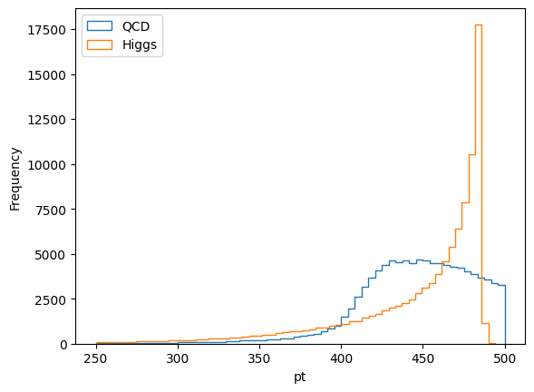

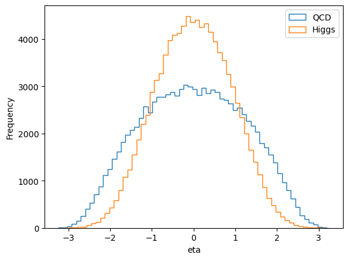

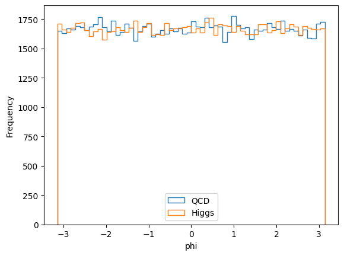

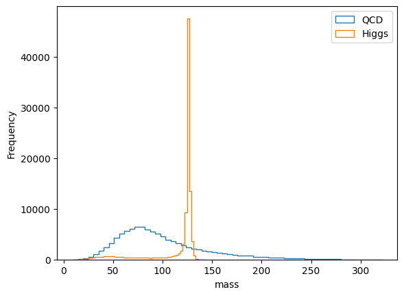

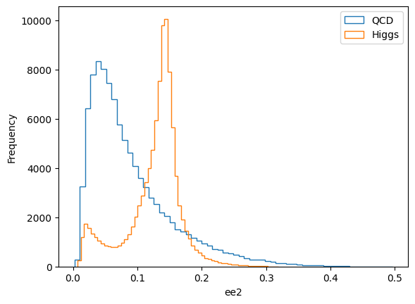

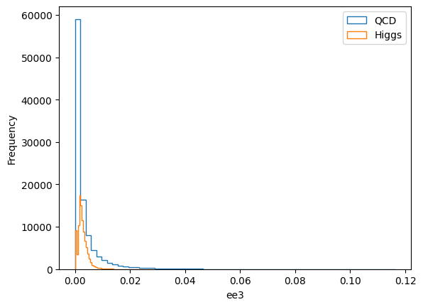

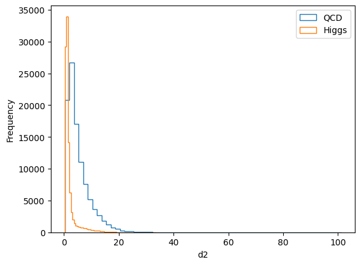

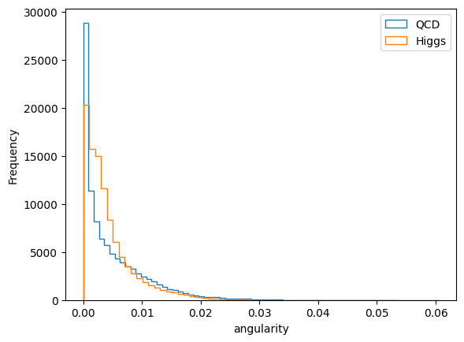

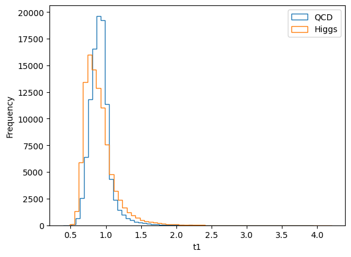

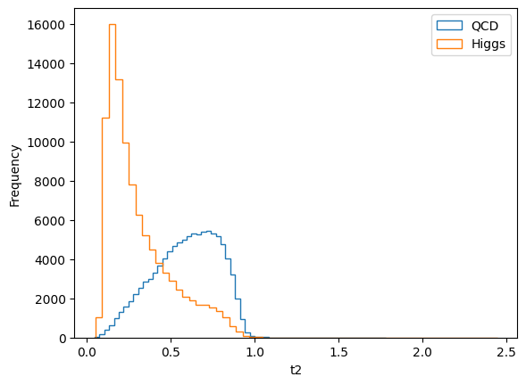

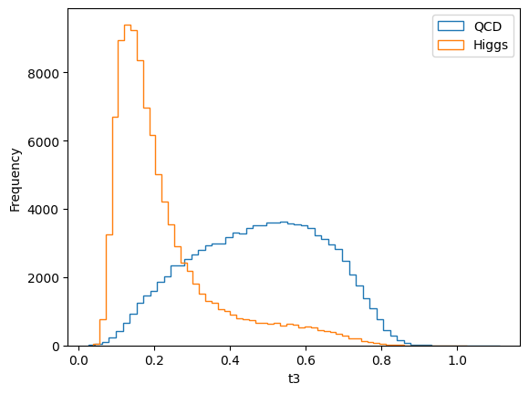

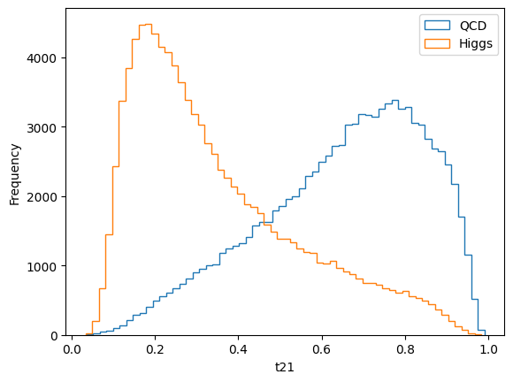

[2 more figures not shown]

```python
import matplotlib.pyplot as plt
#Plotting of Higgs & QCD
def histograms(var):
    plt.hist(qcd[var],bins=60,histtype='step',label='QCD')
    plt.hist(higgs[var],bins=60,histtype='step',label='Higgs')
    plt.xlabel(var)
    plt.ylabel('Frequency')
    plt.legend()
    plt.show()
for label in higgs.keys():
    histograms(label)
```

# Task 2 Exploration (3 points)

We will further explore the LHC data. You will study the correlation between the mass and jet substructure variable d2. The goal will be to see if we can build a simple cut based analysis to increase the discovery of signal over the background. For this task, we will use the low pT files (Sample_pt_250_500).

a) Make two plots of Mass and d2 each with Signal and Background distributions. Describe the shape of the two distribution, commenting on the discrimination power of signal and background. Also make a 2D scatter plot between Mass and d2 for both signal and background.

b) Now assume a signal yield of 100 and a background yield of 20,000, re-weight the signal and background distribution such that they satisfy this yield. Then draw two histograms with the signal stacked on the background. Describe the visibility of observing the signal over the background.

Below is an example of how to apply a weight to a histogram. Pay attention to how a weight is applied. Now adding each entry(one random variable) to the histogram only increase the height by 0.001

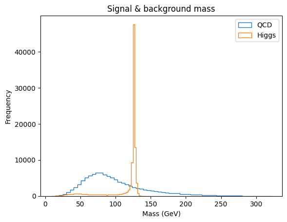

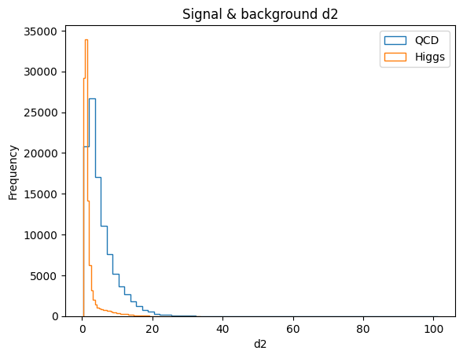

```python
#Mass plot
plt.hist(qcd['mass'],bins=60,histtype='step',label='QCD')
plt.hist(higgs['mass'],bins=60,histtype='step',label='Higgs')
plt.xlabel('Mass (GeV)')
plt.ylabel('Frequency')
plt.title('Signal & background mass')
plt.legend()
plt.show()

#d2 plot
plt.hist(qcd['d2'],bins=60,histtype='step',label='QCD')
plt.hist(higgs['d2'],bins=60,histtype='step',label='Higgs')
plt.xlabel('d2')
plt.ylabel('Frequency')
plt.legend()
plt.title('Signal & background d2')
```

From the mass plot, we can see that the Higgs data has a large peak in which we can easily differentiate it from the background noise.

The d2 plot is somewhat harder to be able to tell, since the QCD & Higgs data overlay each other at a lower d2. However, this initial bump is a good indicator of being able to discriminate it from background data.

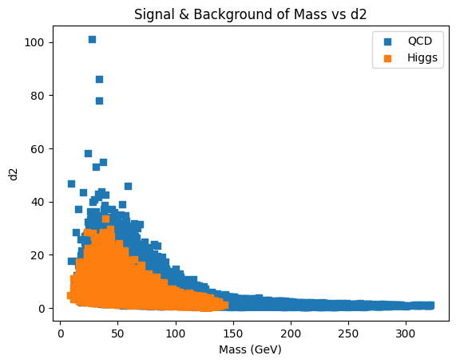

```python
# 2D scatter plot of signal & background for d2 & mass
plt.scatter(qcd['mass'],qcd['d2'],label='QCD',marker=',')
plt.scatter(higgs['mass'],higgs['d2'],label='Higgs',marker=',')
plt.xlabel('Mass (GeV)')
plt.ylabel('d2')
plt.title('Signal & Background of Mass vs d2')
plt.legend()
```

```
100000
100000
```

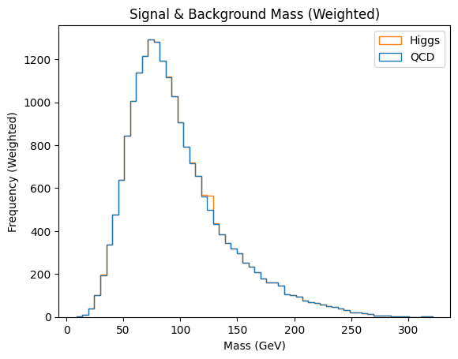

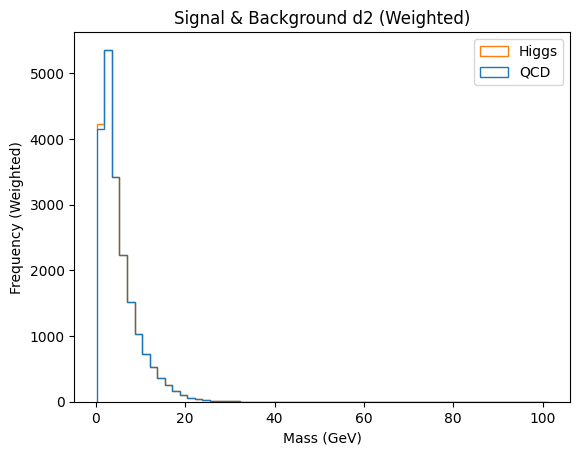

```python
import numpy as np
#Part b
# For finding current yields
print(len(qcd))
print(len(higgs))

# Weight calculations
qcdweight = 20000/len(qcd)
higgsweight = 100/len(higgs)

# Weighted mass plot
plt.hist([qcd['mass'],higgs['mass']],bins=60,histtype='step',
         stacked=True,fill=False,density=False,label=['QCD','Higgs'],
         weights=[qcdweight * np.ones(len(qcd)),higgsweight*np.ones(len(higgs))])
plt.xlabel('Mass (GeV)')
plt.ylabel('Frequency (Weighted)')
plt.legend()
plt.title('Signal & Background Mass (Weighted)')
plt.show()

# Weighted d2 plot
plt.hist([qcd['d2'],higgs['d2']],bins=60,histtype='step',
         stacked=True,fill=False,density=False,label=['QCD','Higgs'],
         weights=[qcdweight * np.ones(len(qcd)),higgsweight*np.ones(len(higgs))])
plt.xlabel('Mass (GeV)')
plt.ylabel('Frequency (Weighted)')
plt.legend()
plt.title('Signal & Background d2 (Weighted)')
```

It's extraordinarily hard to tell the Higgs from the QCD data, since they're virtually exactly on top of each other. I'd assume given the large peaks, though, that it'd be pretty easy to differentiate them form background data.

```python
# import numpy as np
# import matplotlib.pyplot as plt

# np.random.seed(42)
# n_bins = 10
# x = np.random.randn(1000, 1)
# fig, (ax0, ax1) = plt.subplots(nrows=1, ncols=2)

# unweighted_values_inbin, unweighted_bins, _ = ax0.hist(x, n_bins, density=False, histtype='bar')
# ax0.set_title('unweighted histogram')
# print(f"unweighted: the yield is {np.sum(unweighted_values_inbin)}, the area is {np.sum(unweighted_values_inbin) * (unweighted_bins[1] - unweighted_bins[0]) }")

# custom_weight = 0.001
# weighted_values_inbin, weighted_bins, _ = ax1.hist(x, n_bins, density=False, histtype='bar', weights= custom_weight * np.ones(x.shape[0]))
# ax1.set_title('weighted histogram')
# print(f"weighted: the yield is {np.sum(weighted_values_inbin)}, the area is {np.sum(weighted_values_inbin) * (weighted_bins[1] - weighted_bins[0]) }")
# unweighted: the yield is 1000.0, the area is 709.3998830723796
# weighted: the yield is 1.0000000000000007, the area is 0.70939988307238
```

[figure not shown]

Below is an example of how to make a stacked histogram.

```
The shape of rvs is (1000, 3)
```

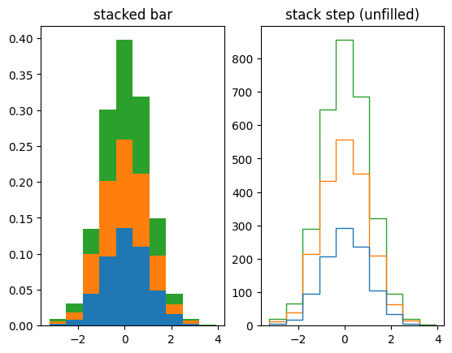

```python
import numpy as np
import matplotlib.pyplot as plt

np.random.seed(42)
n_bins = 10
x = np.random.randn(1000, 3)
fig, (ax0, ax1) = plt.subplots(nrows=1, ncols=2)


ax0.hist(x, n_bins, density=True, histtype='bar', stacked=True)
ax0.set_title('stacked bar')

ax1.hist(x, n_bins, histtype='step', stacked=True, fill=False)
ax1.set_title('stack step (unfilled)')

print(f"The shape of rvs is {x.shape}")
```

[figure not shown]

c) Using the weighted samples from Q2 apply a Mass cut of [120, 130] GeV. Now again make the two histograms as above. Does the Mass distribution look as you expect it? how does the d2 plot compare to the one in Task 2b?

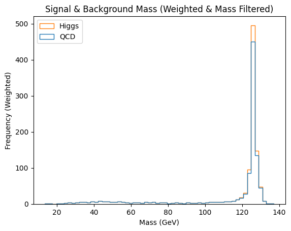

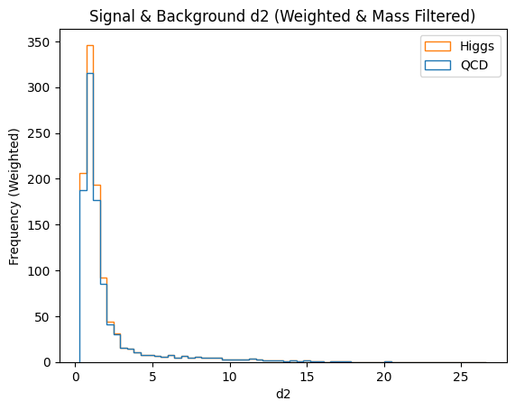

```python
# Higgs mass cuts
higgs_mask = np.logical_and(higgs['mass'] >= 120, higgs['mass'] <= 130)
filt_higgs_masscut=higgs['mass'][higgs_mask]
filt_higgs_d2=higgs['d2'][higgs_mask]

# qcd mass cuts
qcd_mask = np.logical_and(qcd['mass'] >= 120, qcd['mass'] <= 130)
filt_qcd_masscut=higgs['mass'][qcd_mask]
filt_qcd_d2=higgs['d2'][qcd_mask]

# Weighted mass plot w/ mass cut
plt.hist([filt_qcd_masscut,filt_higgs_masscut],bins=60,histtype='step',
         stacked=True,fill=False,density=False,label=['QCD','Higgs'],
         weights=[qcdweight * np.ones(len(filt_qcd_masscut)),higgsweight*np.ones(len(filt_higgs_masscut))])
plt.xlabel('Mass (GeV)')
plt.ylabel('Frequency (Weighted)')
plt.legend()
plt.title('Signal & Background Mass (Weighted & Mass Filtered)')
plt.show()

# # Weighted d2 plot w/ mass cut
plt.hist([filt_qcd_d2,filt_higgs_d2],bins=60,histtype='step',
         stacked=True,fill=False,density=False,label=['QCD','Higgs'],
         weights=[qcdweight * np.ones(len(filt_qcd_masscut)),higgsweight*np.ones(len(filt_higgs_masscut))])
plt.xlabel('d2')
plt.ylabel('Frequency (Weighted)')
plt.legend()
plt.title('Signal & Background d2 (Weighted & Mass Filtered)')
```

# Task3 Significance optimization (4 points)

Now we want to scan over d2 to find a good cut on d2 to increase our significance. The siginificance formula is given below(it's a good exercise to think about the derivation of the formula), and it is in the unit of $\sigma$:

$Significance = \frac{N_{signal}}{\sqrt{N_{bkg}}}$

We want to reject as many bkg as possible while keep the signal to make signal more visible(siginificant).

Now, think the following questions:

1. Inspect the d2 distribution after you apply the mass cut, how does it change compared to that without any mass cut?
2. Let's say you choose a d2 cut value of 4, do you want to keep the histogram below 4 of above 4? Which makes signal more siginificant?
3. What range can be chosen to scan the d2 cut?

After you have some ideas, choose a range to scan d2. For each d2 value you can calculate a significane. Then plot significance vs. d2 cut value, choose the cut value corresponding to 3 $\sigma$. Now plot the Mass distributions with the mass cut and with the d2 cut. What do you observe in this plot? What is the significance value with these two cuts(mass and t2)?

A good checking is that compare the significance before any d2 cut and with a very large d2 cut.

The plot below is a exmaple of how the signifiance vs cut value might look like:

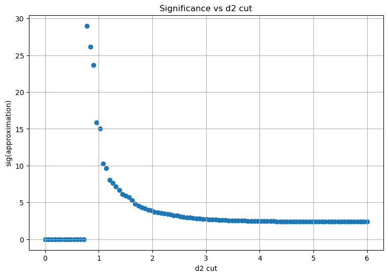

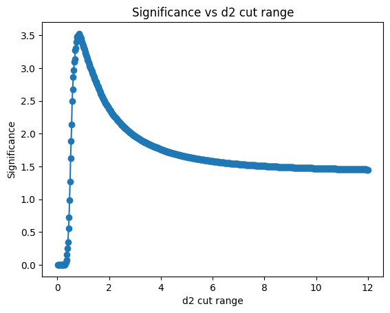

```python
d2range = np.linspace(0.01,12,600)
signif=[]
# Calculate weights for each value within range
# Added tiny value to ensure qcdweight != 0
for i in d2range:
    qcdweight=len(qcd.loc[(qcd['d2'] <= i)])/(10**(5)*20000) + 1e-99
    higgsweight=len(higgs.loc[(higgs['d2'] <= i)])/(10**(5)*100)
    signif.append(higgsweight/np.sqrt(qcdweight))

plt.scatter(d2range,signif)
plt.plot(d2range,signif)
plt.xlabel('d2 cut range')
plt.ylabel('Significance')
plt.title('Significance vs d2 cut range')
```

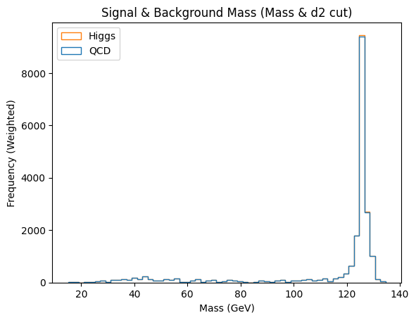

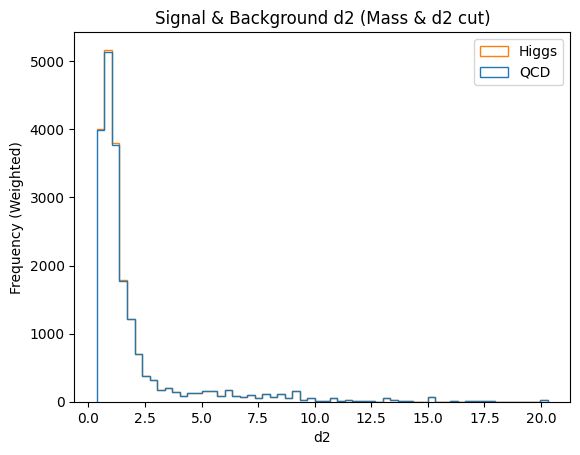

```python
# Applying cuts for where significance > 2.5
sig_loc = np.where(np.array(signif) > 2.5)[0]
d2_min, d2_max = d2range[sig_loc[0]], d2range[sig_loc[-1]]

# Masks
higgsd2mask=np.logical_and.reduce((higgs['mass'] >= 120, higgs['mass'] <= 130,
                                   higgs['d2']<d2_max,higgs['d2']>d2_min))
qcdd2mask=np.logical_and.reduce((qcd['mass'] >= 120, qcd['mass'] <= 130,
                                   qcd['d2']<d2_max,qcd['d2']>d2_min))
filt_higgs_mass=higgs['mass'][higgsd2mask]
filt_higgs_d2=higgs['d2'][higgsd2mask]
filt_qcd_mass=higgs['mass'][qcdd2mask]
filt_qcd_d2=higgs['d2'][qcdd2mask]

# Yields & weights
higgs_yield=len(filt_higgs_mass)
qcd_yield=len(filt_qcd_mass)

higgs_weight=100/higgs_yield
qcd_weight=20000/qcd_yield

# Mass cut plots
plt.hist([filt_qcd_mass,filt_higgs_mass],bins=60,histtype='step',
         stacked=True,fill=False,density=False,label=['QCD','Higgs'],
         weights=[np.full(qcd_yield,qcd_weight),np.full(higgs_yield,higgs_weight)])
plt.xlabel('Mass (GeV)')
plt.ylabel('Frequency (Weighted)')
plt.legend()
plt.title('Signal & Background Mass (Mass & d2 cut)')
plt.show()

# d2 cut plots
plt.hist([filt_qcd_d2,filt_higgs_d2],bins=60,histtype='step',
         stacked=True,fill=False,density=False,label=['QCD','Higgs'],
         weights=[np.full(qcd_yield,qcd_weight),np.full(higgs_yield,higgs_weight)])
plt.xlabel('d2')
plt.ylabel('Frequency (Weighted)')
plt.legend()
plt.title('Signal & Background d2 (Mass & d2 cut)')
```

The mass distribution with both cuts has a much higher frequency & the Higgs peak is much closer to the QCD peak. Or perhaps it's just hard to tell because the values are larger.

```python
print('After mass cut')
print(f'Higgs yield: {len(filt_higgs_masscut)}, QCD yield: {len(filt_qcd_masscut)}')
print('After d2 cut')
print(f'Higgs yield: {higgs_yield}, QCD yield: {qcd_yield}')
```

```
After mass cut
Higgs yield: 75847, QCD yield: 4901
After d2 cut
Higgs yield: 61720, QCD yield: 1267
```

We see here without even having to do calculations that the d2 cut made the significance much larger, since the signal yield didn't drop nearly as much as the background yield did.